# Coursework Report

*N* removed NAs: 3

*N* removed typo: 1

*N* removed <18: 29

*N* total clean: 117

| Group | *N* | *M*<sub>age</sub> | *M*<sub>rating</sub> |
| --- | --- | --- | --- |
| Control | 59 | 20.9 | 6.16 |
| Experim | 58 | 20.7 | 5.47 |

**Main analysis results**

*t*(115) = 4.35, *p* < .001

[interactive chart not shown]

[figure not shown]

[interactive chart not shown]

# Coursework Report

Analysing Data, Spring 2020

# Methods

## Participants

Table 1: Participants descriptives by experimental condition

| Condition | *N* | *M*<sub>age</sub> | *SD*<sub>age</sub> |
| --- | --- | --- | --- |
| control | 59 | 20.9 | 2.11 |
| experimental | 58 | 20.7 | 2.14 |

## Design

Does colour influence attractiveness? This experiment, a replication of Elliot et al., (2010) investigated whether viewing men on different colour backgrounds influences how women perceive male attractiveness. Both, the control and experimental groups saw one of two black and white photos of men on a background for about 5 seconds. The control group saw the pictures on a white background whereas the experimental group saw the pictures on a red background. Elliot et al., (2010) chose white because they considered it to be the most neutral colour available. Thus, colour was the independent categorical variable, with two levels: red - experimental and white - control. The participants rated the pictures on a scale ranging from 1 (not attractive at all) to 9 (extremely attractive) for three questions - “How attractive do you think this person is?”, “How pleasant is this person to look at?” and “If I were to meet the person in this picture face to face, I would think he is attractive”. Thus, the attractiveness ratings were the continuous and dependent variable. With the help of a composite score and an independent t-test we investigated whether our data supports the hypothesis that the colour of the frame influences how women perceive men´s attractiveness.

# Results

After calculating the composite score - the sum of the scores of all three questions divided by three - we compared the mean attractiveness ratings of the groups. Contrary to the original experiment, the control group had a higher attractiveness mean rating (*M* = 6.16) than the experimental group (*M* = 5.47). Using an independent t-test, we showed that the difference of means from the attractiveness ratings from both groups was statistically significant (*M*<sub>diff</sub> = 0.69, 95% CI [0.38, 1.01], *t* (115) = 4.35, *p* = .00003) and enough to conclude that the two groups constitute two different populations. The results therefore do not support the hypothesis that the colour red will increase attractiveness perception of men. Table 2 summarises the mean ratings by condition. In addition, the plot visualises the obtained results.

Table 2: Summary of mean ratings by experimental condition

| Condition | N | Composite score | SD |
| --- | --- | --- | --- |
| control | 59 | 6.16 | 0.87 |
| experimental | 58 | 5.47 | 0.85 |

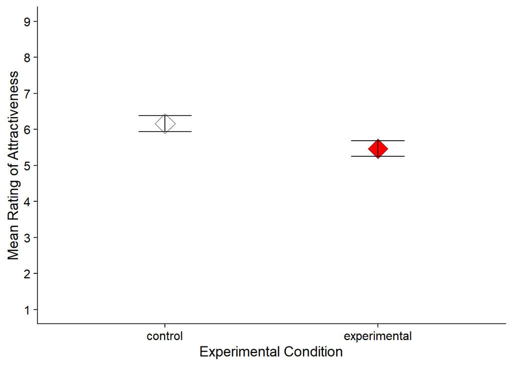

Plot 1: Mean attractiveness rating per condition

# Discussion

This replication attempt of Elliot et al., (2010) investigated whether their findings of the positive effect of the colour red on perceived attractiveness is replicable. Our results did not support their hypothesis that the colour red increases attractiveness. Our statistical results showed that there was a statistically significant difference between the attractiveness ratings of both groups. Contrary to expectations however, the control group – picture of men on a white background – received a higher mean attractiveness rating compared to the experimental group – picture of men on a red background. Thus, our results found the opposite patterns of the original experiment and thus failed to support their findings. Other experiments conducted, also failed to show the effect of the colour red on attractiveness ratings (e.g. Peperkoorn et al., 2016). We can therefore conclude that there is no clear evidence for the positive effect of red on perceived male attractiveness for women. Taken together, our and Peperkoorn et al., (2016) results demonstrate the lack of supportive evidence for Elliot’s hypothesis.

Our experiment however, also had its limitations. We investigated the effect only on young female undergraduates in the United States ranging from 18 to 27 years old. Therefore, our results do not provide any evidence of how red influences attractiveness perception in older women, women with a different academic background, women of this age group in full time employment or women from different cultures or countries. In addition, only two background colours – red and white – were used in this experiment. In another experiment conducted by Elliot et al., (2010) the researchers compared the effect on attractiveness ratings of red with blue and grey and found the same effects as with the colour white. As our results could not support their findings, further research on the effects of red on attractiveness perception has to be conducted to reach a clearer understanding of this colour’s effects. In addition, further research using different colour combinations may also provide evidence for the impact of colour on perceived attractiveness by women. Research should also be conducted with women from different demographics and other countries and cultures as we cannot conclude anything about this from our results. This would be an important contribution towards better understanding of this research field. Future research on other animals, particularly mammals may provide additional insights into any underlying factors and inherited patterns regarding potential colour effects on female attractiveness perception. This may provide us with evidence from a different perspective. Kodric-Brown & Johnson (2002), for example showed that male guppies with stronger UV-reflective colours are more likely to increased their attractiveness to female guppies.

Is the “red effect” replicable and does it really exist? In conclusion, our replication of Elliot et al.,(2010) did not support their findings, that the colour red positively influences attractiveness perception. Rather, our results showed the opposite effect, resulting in higher attractiveness ratings when viewing a men on a white background. This implies that answering this question is not as simple and that this research field has to be investigated further in order to get a better understanding of the underlying factors. The suggestions about further research mentioned above should be taken into consideration for further investigations of this question.

# References

Elliot, A. J., & Maier, M. A. (2013). The red-attractiveness effect, applying the Ioannidis and Trikalinos (2007b) test, and the broader scientific context: A reply to Francis (2013).

Elliot, A. J., Niesta Kayser, D., Greitemeyer, T., Lichtenfeld, S., Gramzow, R. H., Maier, M. A., & Liu, H. (2010). Red, rank, and romance in women viewing men. Journal of Experimental Psychology: General, 139(3), 399.

Kodric-Brown, A., & Johnson, S. C. (2002). Ultraviolet reflectance patterns of male guppies enhance their attractiveness to females. Animal Behaviour, 63(2), 391–396.

Peperkoorn, L. S., Roberts, S. C., & Pollet, T. V. (2016). Revisiting the red effect on attractiveness and sexual receptivity: No effect of the color red on human mate preferences. Evolutionary Psychology, 14(4), 1474704916673841.